# Grand Fir / Snowbrush Microbiome

2024-04-30

**Preliminary data exploration**

**Contaminant ASVs were identified with the prevalence method using the *decontam* package.**

# **Plant measures overview**

**Scaled-centered plant ‘health’ measures, broken down by treatment factors.**

**Figure 1**

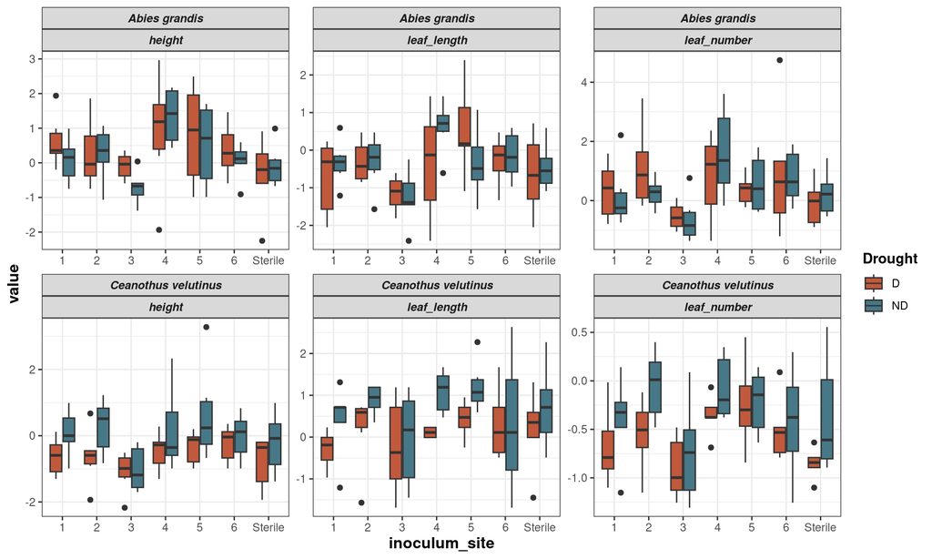

**Model output**

Formula: `value ~ drought * host * site + (1|block))`

**Table 1**

| effect | term | estimate | std.error | statistic | df | p.value |
| --- | --- | --- | --- | --- | --- | --- |
| fixed | (Intercept) | 0.152 | 0.270 | 0.563 | 19.346 | 0.580 |
| fixed | droughtND | -0.119 | 0.266 | -0.449 | 458.953 | 0.654 |
| fixed | hostCeanothus velutinus | -0.619 | 0.266 | -2.329 | 458.953 | 0.020 |
| fixed | inoculum_site2 | 0.274 | 0.266 | 1.029 | 458.953 | 0.304 |
| fixed | inoculum_site3 | -0.677 | 0.266 | -2.547 | 458.953 | 0.011 |
| fixed | inoculum_site4 | 0.370 | 0.266 | 1.394 | 458.953 | 0.164 |
| fixed | inoculum_site5 | 0.485 | 0.266 | 1.826 | 458.953 | 0.069 |
| fixed | inoculum_site6 | 0.259 | 0.266 | 0.974 | 458.953 | 0.331 |
| fixed | inoculum_siteSterile | -0.435 | 0.266 | -1.636 | 458.953 | 0.103 |
| fixed | droughtND:hostCeanothus velutinus | 0.758 | 0.382 | 1.986 | 458.980 | 0.048 |
| fixed | droughtND:inoculum_site2 | -0.171 | 0.376 | -0.455 | 458.953 | 0.650 |
| fixed | droughtND:inoculum_site3 | -0.124 | 0.381 | -0.325 | 464.972 | 0.745 |
| fixed | droughtND:inoculum_site4 | 0.861 | 0.376 | 2.290 | 458.953 | 0.022 |
| fixed | droughtND:inoculum_site5 | -0.209 | 0.376 | -0.556 | 458.953 | 0.578 |
| fixed | droughtND:inoculum_site6 | 0.004 | 0.376 | 0.010 | 458.953 | 0.992 |
| fixed | droughtND:inoculum_siteSterile | 0.374 | 0.376 | 0.994 | 458.953 | 0.321 |
| fixed | hostCeanothus velutinus:inoculum_site2 | -0.070 | 0.376 | -0.187 | 458.953 | 0.852 |
| fixed | hostCeanothus velutinus:inoculum_site3 | 0.469 | 0.376 | 1.247 | 458.953 | 0.213 |
| fixed | hostCeanothus velutinus:inoculum_site4 | 0.063 | 0.386 | 0.164 | 459.021 | 0.870 |
| fixed | hostCeanothus velutinus:inoculum_site5 | -0.005 | 0.376 | -0.013 | 458.953 | 0.990 |
| fixed | hostCeanothus velutinus:inoculum_site6 | 0.004 | 0.386 | 0.010 | 459.009 | 0.992 |
| fixed | hostCeanothus velutinus:inoculum_siteSterile | 0.603 | 0.386 | 1.564 | 459.021 | 0.118 |
| fixed | droughtND:hostCeanothus velutinus:inoculum_site2 | 0.243 | 0.536 | 0.453 | 458.967 | 0.651 |
| fixed | droughtND:hostCeanothus velutinus:inoculum_site3 | -0.364 | 0.540 | -0.675 | 463.713 | 0.500 |
| fixed | droughtND:hostCeanothus velutinus:inoculum_site4 | -1.004 | 0.543 | -1.849 | 459.043 | 0.065 |
| fixed | droughtND:hostCeanothus velutinus:inoculum_site5 | 0.176 | 0.536 | 0.328 | 458.967 | 0.743 |
| fixed | droughtND:hostCeanothus velutinus:inoculum_site6 | -0.412 | 0.543 | -0.760 | 458.986 | 0.448 |
| fixed | droughtND:hostCeanothus velutinus:inoculum_siteSterile | -0.592 | 0.543 | -1.090 | 459.043 | 0.276 |

# **Inoculum communities overview**

## **Taxonomic overview**

### **Bacteria**

**Figure 2**

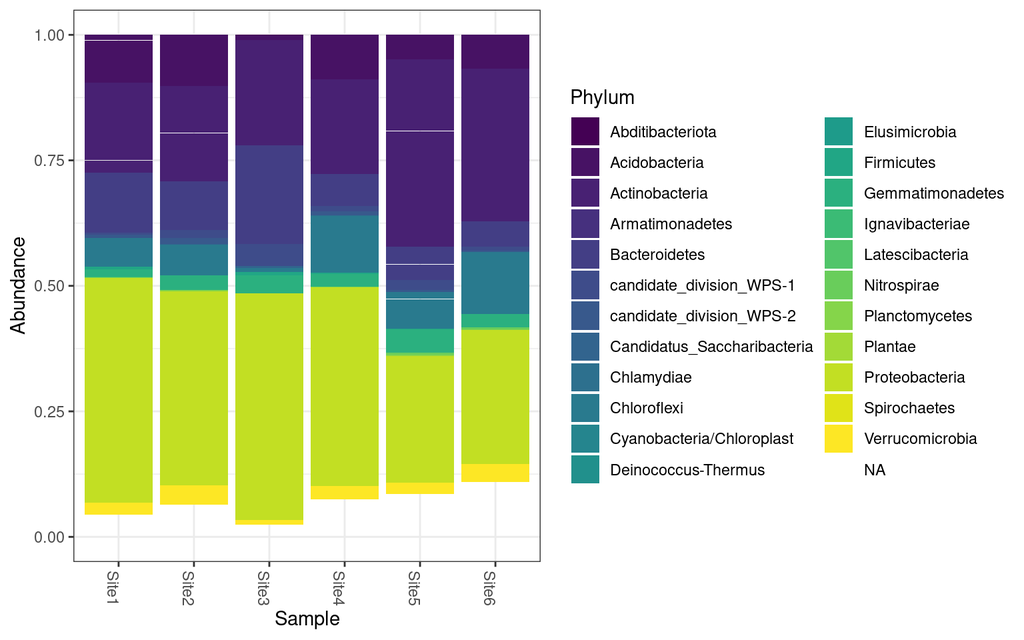

**Alpha diversity**

Effect of Shannon diversity on plant measures

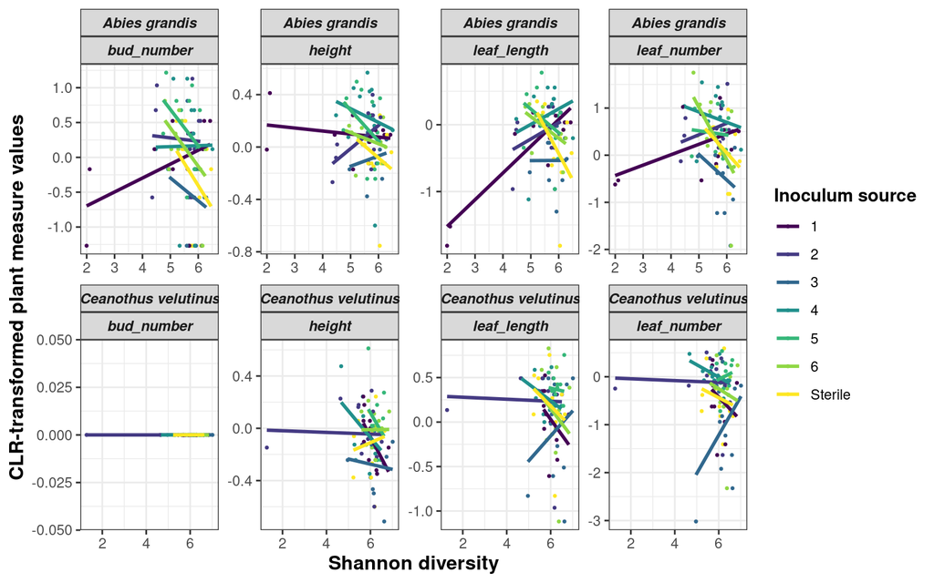

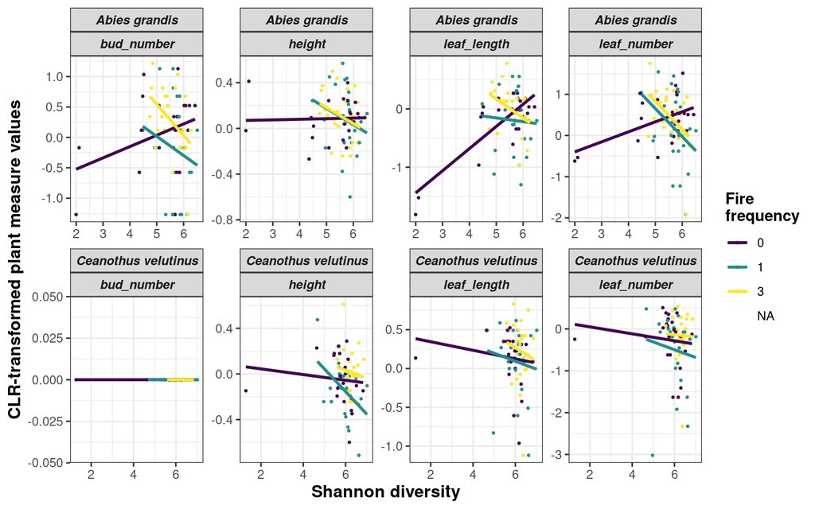

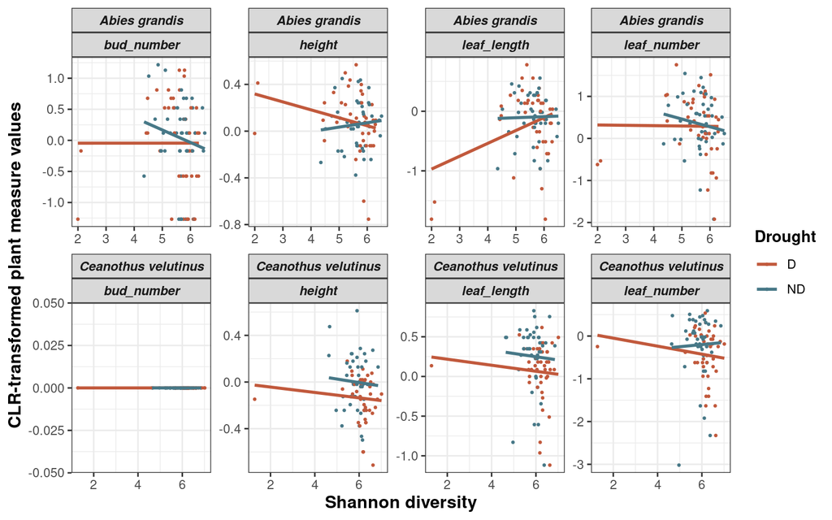

```
## overall_transformed_plant_value ~ Shannon * host * drought *
##     inoculum_site + (1 | block)
## <environment: 0x556928702540>
```

**Table 2**

| effect | group | term | estimate | std.error | statistic | df | p.value |
| --- | --- | --- | --- | --- | --- | --- | --- |
| fixed | NA | (Intercept) | -1.226 | 0.507 | -2.417 | 122.238 | 0.017 |
| fixed | NA | Shannon | 0.301 | 0.101 | 2.993 | 609.763 | 0.003 |
| fixed | NA | hostCeanothus velutinus | 0.984 | 2.559 | 0.385 | 610.106 | 0.701 |
| fixed | NA | droughtND | -0.187 | 2.351 | -0.079 | 609.423 | 0.937 |
| fixed | NA | inoculum_site2 | 1.378 | 1.915 | 0.720 | 609.868 | 0.472 |
| fixed | NA | inoculum_site3 | 1.749 | 4.502 | 0.389 | 610.099 | 0.698 |
| fixed | NA | inoculum_site4 | 1.827 | 1.868 | 0.978 | 610.007 | 0.328 |
| fixed | NA | inoculum_site5 | 6.697 | 3.448 | 1.942 | 609.951 | 0.053 |
| fixed | NA | inoculum_site6 | 6.414 | 1.849 | 3.470 | 610.406 | 0.001 |
| fixed | NA | inoculum_siteSterile | 7.260 | 2.633 | 2.757 | 609.891 | 0.006 |
| fixed | NA | Shannon:hostCeanothus velutinus | -0.301 | 0.424 | -0.709 | 610.132 | 0.478 |
| fixed | NA | Shannon:droughtND | -0.033 | 0.409 | -0.080 | 609.263 | 0.936 |
| fixed | NA | hostCeanothus velutinus:droughtND | 17.677 | 8.477 | 2.085 | 611.147 | 0.037 |
| fixed | NA | Shannon:inoculum_site2 | -0.223 | 0.345 | -0.647 | 609.967 | 0.518 |
| fixed | NA | Shannon:inoculum_site3 | -0.477 | 0.754 | -0.633 | 610.113 | 0.527 |
| fixed | NA | Shannon:inoculum_site4 | -0.334 | 0.352 | -0.948 | 610.051 | 0.344 |
| fixed | NA | Shannon:inoculum_site5 | -1.150 | 0.612 | -1.879 | 609.963 | 0.061 |
| fixed | NA | Shannon:inoculum_site6 | -1.153 | 0.330 | -3.495 | 610.521 | 0.001 |
| fixed | NA | Shannon:inoculum_siteSterile | -1.391 | 0.457 | -3.045 | 609.950 | 0.002 |
| fixed | NA | hostCeanothus velutinus:inoculum_site2 | -1.457 | 3.239 | -0.450 | 610.782 | 0.653 |
| fixed | NA | hostCeanothus velutinus:inoculum_site3 | -2.040 | 6.432 | -0.317 | 611.675 | 0.751 |
| fixed | NA | hostCeanothus velutinus:inoculum_site4 | -5.726 | 4.534 | -1.263 | 610.573 | 0.207 |
| fixed | NA | hostCeanothus velutinus:inoculum_site5 | -9.239 | 6.982 | -1.323 | 610.067 | 0.186 |
| fixed | NA | hostCeanothus velutinus:inoculum_site6 | -16.444 | 7.791 | -2.111 | 608.880 | 0.035 |
| fixed | NA | hostCeanothus velutinus:inoculum_siteSterile | -7.195 | 4.427 | -1.625 | 611.688 | 0.105 |
| fixed | NA | droughtND:inoculum_site2 | -1.482 | 3.252 | -0.456 | 608.582 | 0.649 |
| fixed | NA | droughtND:inoculum_site3 | 1.646 | 5.810 | 0.283 | 615.792 | 0.777 |
| fixed | NA | droughtND:inoculum_site4 | 2.497 | 3.822 | 0.653 | 609.716 | 0.514 |
| fixed | NA | droughtND:inoculum_site5 | -2.968 | 4.505 | -0.659 | 609.380 | 0.510 |
| fixed | NA | droughtND:inoculum_site6 | -3.067 | 3.816 | -0.804 | 609.535 | 0.422 |
| fixed | NA | droughtND:inoculum_siteSterile | -5.102 | 4.529 | -1.127 | 608.940 | 0.260 |
| fixed | NA | Shannon:hostCeanothus velutinus:droughtND | -2.903 | 1.447 | -2.007 | 611.120 | 0.045 |
| fixed | NA | Shannon:hostCeanothus velutinus:inoculum_site2 | 0.265 | 0.551 | 0.481 | 610.838 | 0.631 |
| fixed | NA | Shannon:hostCeanothus velutinus:inoculum_site3 | 0.467 | 1.042 | 0.448 | 611.699 | 0.654 |
| fixed | NA | Shannon:hostCeanothus velutinus:inoculum_site4 | 1.033 | 0.764 | 1.352 | 610.587 | 0.177 |
| fixed | NA | Shannon:hostCeanothus velutinus:inoculum_site5 | 1.626 | 1.148 | 1.416 | 610.110 | 0.157 |
| fixed | NA | Shannon:hostCeanothus velutinus:inoculum_site6 | 2.803 | 1.253 | 2.237 | 608.849 | 0.026 |
| fixed | NA | Shannon:hostCeanothus velutinus:inoculum_siteSterile | 1.380 | 0.739 | 1.868 | 611.677 | 0.062 |
| fixed | NA | Shannon:droughtND:inoculum_site2 | 0.315 | 0.576 | 0.546 | 608.588 | 0.585 |
| fixed | NA | Shannon:droughtND:inoculum_site3 | -0.280 | 0.990 | -0.283 | 615.999 | 0.777 |
| fixed | NA | Shannon:droughtND:inoculum_site4 | -0.250 | 0.673 | -0.372 | 609.580 | 0.710 |
| fixed | NA | Shannon:droughtND:inoculum_site5 | 0.562 | 0.795 | 0.706 | 609.339 | 0.480 |
| fixed | NA | Shannon:droughtND:inoculum_site6 | 0.615 | 0.686 | 0.897 | 609.495 | 0.370 |
| fixed | NA | Shannon:droughtND:inoculum_siteSterile | 1.016 | 0.779 | 1.304 | 608.901 | 0.193 |
| fixed | NA | hostCeanothus velutinus:droughtND:inoculum_site2 | -13.825 | 9.008 | -1.535 | 610.965 | 0.125 |
| fixed | NA | hostCeanothus velutinus:droughtND:inoculum_site3 | -23.837 | 11.167 | -2.135 | 614.160 | 0.033 |
| fixed | NA | hostCeanothus velutinus:droughtND:inoculum_site4 | -12.860 | 9.807 | -1.311 | 610.900 | 0.190 |
| fixed | NA | hostCeanothus velutinus:droughtND:inoculum_site5 | -6.875 | 11.623 | -0.591 | 609.219 | 0.554 |
| fixed | NA | hostCeanothus velutinus:droughtND:inoculum_site6 | 1.508 | 11.603 | 0.130 | 609.041 | 0.897 |
| fixed | NA | hostCeanothus velutinus:droughtND:inoculum_siteSterile | -11.042 | 9.889 | -1.117 | 610.051 | 0.265 |
| fixed | NA | Shannon:hostCeanothus velutinus:droughtND:inoculum_site2 | 2.325 | 1.546 | 1.503 | 610.908 | 0.133 |
| fixed | NA | Shannon:hostCeanothus velutinus:droughtND:inoculum_site3 | 4.032 | 1.880 | 2.145 | 614.514 | 0.032 |
| fixed | NA | Shannon:hostCeanothus velutinus:droughtND:inoculum_site4 | 2.020 | 1.678 | 1.204 | 610.839 | 0.229 |
| fixed | NA | Shannon:hostCeanothus velutinus:droughtND:inoculum_site5 | 1.194 | 1.944 | 0.614 | 609.262 | 0.539 |
| fixed | NA | Shannon:hostCeanothus velutinus:droughtND:inoculum_site6 | -0.260 | 1.938 | -0.134 | 609.046 | 0.893 |
| fixed | NA | Shannon:hostCeanothus velutinus:droughtND:inoculum_siteSterile | 1.757 | 1.684 | 1.044 | 609.997 | 0.297 |
| ran_pars | block | sd__(Intercept) | 0.537 | NA | NA | NA | NA |
| ran_pars | Residual | sd__Observation | 0.812 | NA | NA | NA | NA |

### **Fungi**

**Figure 3**

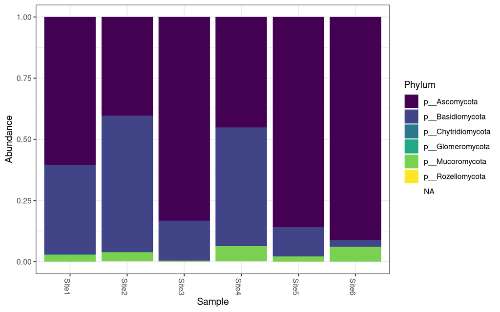

**Alpha diversity**

Effect of Shannon diversity on plant measures

**Table 3**

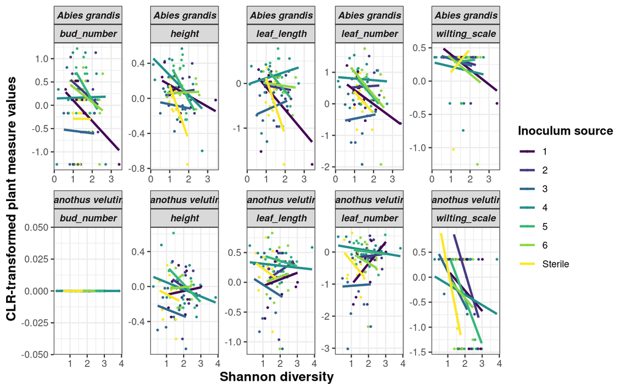

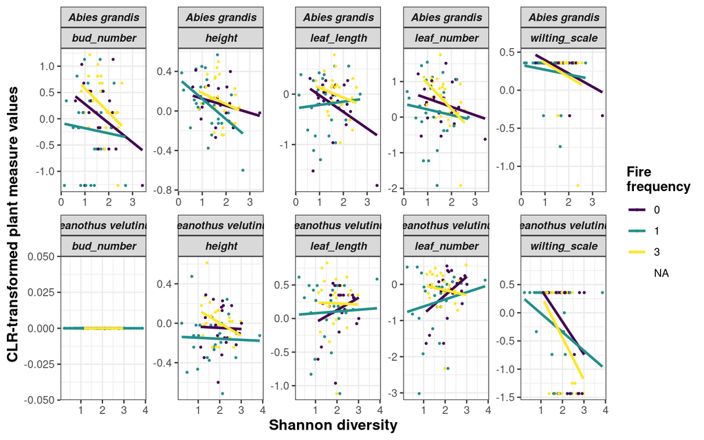

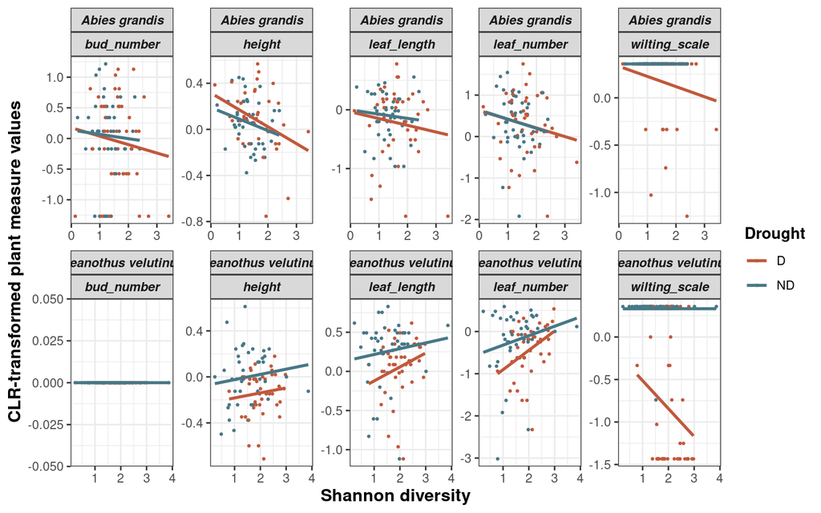

```
## overall_transformed_plant_value ~ Shannon * host * drought *
##     inoculum_site + (1 | block)
## <environment: 0x556928702540>
```

| effect | group | term | estimate | std.error | statistic | df | p.value |
| --- | --- | --- | --- | --- | --- | --- | --- |
| fixed | NA | (Intercept) | 0.849 | 0.357 | 2.379 | 175.175 | 0.018 |
| fixed | NA | Shannon | -0.494 | 0.187 | -2.639 | 781.982 | 0.008 |
| fixed | NA | hostCeanothus velutinus | -0.898 | 0.731 | -1.228 | 781.153 | 0.220 |
| fixed | NA | droughtND | -0.100 | 0.586 | -0.170 | 780.300 | 0.865 |
| fixed | NA | inoculum_site2 | -0.307 | 0.780 | -0.394 | 780.746 | 0.694 |
| fixed | NA | inoculum_site3 | -0.923 | 0.625 | -1.478 | 782.135 | 0.140 |
| fixed | NA | inoculum_site4 | -0.526 | 0.439 | -1.199 | 778.320 | 0.231 |
| fixed | NA | inoculum_site5 | -0.416 | 0.899 | -0.463 | 779.825 | 0.644 |
| fixed | NA | inoculum_site6 | 1.264 | 0.950 | 1.330 | 781.558 | 0.184 |
| fixed | NA | inoculum_siteSterile | -0.601 | 0.835 | -0.720 | 779.664 | 0.472 |
| fixed | NA | Shannon:hostCeanothus velutinus | 0.253 | 0.368 | 0.686 | 781.374 | 0.493 |
| fixed | NA | Shannon:droughtND | 0.071 | 0.391 | 0.182 | 780.743 | 0.856 |
| fixed | NA | hostCeanothus velutinus:droughtND | 0.423 | 1.009 | 0.419 | 779.046 | 0.676 |
| fixed | NA | Shannon:inoculum_site2 | 0.464 | 0.412 | 1.127 | 780.882 | 0.260 |
| fixed | NA | Shannon:inoculum_site3 | 0.286 | 0.407 | 0.703 | 782.551 | 0.482 |
| fixed | NA | Shannon:inoculum_site4 | 0.472 | 0.272 | 1.733 | 778.563 | 0.084 |
| fixed | NA | Shannon:inoculum_site5 | 0.561 | 0.521 | 1.077 | 779.847 | 0.282 |
| fixed | NA | Shannon:inoculum_site6 | -0.426 | 0.463 | -0.921 | 781.844 | 0.357 |
| fixed | NA | Shannon:inoculum_siteSterile | 0.148 | 0.573 | 0.259 | 779.993 | 0.796 |
| fixed | NA | hostCeanothus velutinus:inoculum_site2 | -1.597 | 1.728 | -0.924 | 783.189 | 0.356 |
| fixed | NA | hostCeanothus velutinus:inoculum_site3 | 1.317 | 1.087 | 1.212 | 779.267 | 0.226 |
| fixed | NA | hostCeanothus velutinus:inoculum_site4 | 1.081 | 1.230 | 0.879 | 780.948 | 0.379 |
| fixed | NA | hostCeanothus velutinus:inoculum_site5 | 0.875 | 1.388 | 0.630 | 778.872 | 0.529 |
| fixed | NA | hostCeanothus velutinus:inoculum_site6 | -1.300 | 1.398 | -0.930 | 779.092 | 0.353 |
| fixed | NA | hostCeanothus velutinus:inoculum_siteSterile | 3.604 | 2.018 | 1.786 | 782.650 | 0.074 |
| fixed | NA | droughtND:inoculum_site2 | -0.134 | 1.054 | -0.128 | 778.928 | 0.899 |
| fixed | NA | droughtND:inoculum_site3 | -0.704 | 0.936 | -0.752 | 783.662 | 0.452 |
| fixed | NA | droughtND:inoculum_site4 | 0.278 | 0.730 | 0.381 | 779.650 | 0.703 |
| fixed | NA | droughtND:inoculum_site5 | 1.726 | 1.308 | 1.320 | 779.211 | 0.187 |
| fixed | NA | droughtND:inoculum_site6 | -1.982 | 1.176 | -1.686 | 781.343 | 0.092 |
| fixed | NA | droughtND:inoculum_siteSterile | -0.932 | 1.574 | -0.592 | 779.049 | 0.554 |
| fixed | NA | Shannon:hostCeanothus velutinus:droughtND | 0.107 | 0.564 | 0.189 | 779.603 | 0.850 |
| fixed | NA | Shannon:hostCeanothus velutinus:inoculum_site2 | 0.401 | 0.759 | 0.529 | 783.178 | 0.597 |
| fixed | NA | Shannon:hostCeanothus velutinus:inoculum_site3 | -0.635 | 0.624 | -1.017 | 779.000 | 0.309 |
| fixed | NA | Shannon:hostCeanothus velutinus:inoculum_site4 | -0.621 | 0.606 | -1.025 | 781.143 | 0.306 |
| fixed | NA | Shannon:hostCeanothus velutinus:inoculum_site5 | -0.621 | 0.703 | -0.883 | 779.016 | 0.377 |
| fixed | NA | Shannon:hostCeanothus velutinus:inoculum_site6 | 0.524 | 0.674 | 0.778 | 779.068 | 0.437 |
| fixed | NA | Shannon:hostCeanothus velutinus:inoculum_siteSterile | -2.208 | 1.304 | -1.693 | 782.565 | 0.091 |
| fixed | NA | Shannon:droughtND:inoculum_site2 | 0.018 | 0.642 | 0.028 | 779.055 | 0.978 |
| fixed | NA | Shannon:droughtND:inoculum_site3 | 0.468 | 0.656 | 0.713 | 761.413 | 0.476 |
| fixed | NA | Shannon:droughtND:inoculum_site4 | 0.336 | 0.516 | 0.651 | 780.553 | 0.515 |
| fixed | NA | Shannon:droughtND:inoculum_site5 | -1.160 | 0.814 | -1.425 | 779.215 | 0.155 |
| fixed | NA | Shannon:droughtND:inoculum_site6 | 1.144 | 0.662 | 1.729 | 781.593 | 0.084 |
| fixed | NA | Shannon:droughtND:inoculum_siteSterile | 1.043 | 1.199 | 0.870 | 779.158 | 0.384 |
| fixed | NA | hostCeanothus velutinus:droughtND:inoculum_site2 | 3.098 | 2.246 | 1.379 | 783.493 | 0.168 |
| fixed | NA | hostCeanothus velutinus:droughtND:inoculum_site3 | 0.031 | 1.488 | 0.021 | 782.971 | 0.984 |
| fixed | NA | hostCeanothus velutinus:droughtND:inoculum_site4 | -0.831 | 1.480 | -0.561 | 780.610 | 0.575 |
| fixed | NA | hostCeanothus velutinus:droughtND:inoculum_site5 | -2.121 | 1.903 | -1.114 | 781.010 | 0.265 |
| fixed | NA | hostCeanothus velutinus:droughtND:inoculum_site6 | 1.765 | 1.935 | 0.912 | 779.142 | 0.362 |
| fixed | NA | hostCeanothus velutinus:droughtND:inoculum_siteSterile | -2.625 | 2.547 | -1.031 | 780.772 | 0.303 |
| fixed | NA | Shannon:hostCeanothus velutinus:droughtND:inoculum_site2 | -1.282 | 1.099 | -1.166 | 783.243 | 0.244 |
| fixed | NA | Shannon:hostCeanothus velutinus:droughtND:inoculum_site3 | -0.417 | 1.000 | -0.417 | 782.862 | 0.677 |
| fixed | NA | Shannon:hostCeanothus velutinus:droughtND:inoculum_site4 | -0.040 | 0.805 | -0.050 | 781.159 | 0.960 |
| fixed | NA | Shannon:hostCeanothus velutinus:droughtND:inoculum_site5 | 1.334 | 1.075 | 1.240 | 781.134 | 0.215 |
| fixed | NA | Shannon:hostCeanothus velutinus:droughtND:inoculum_site6 | -1.164 | 1.046 | -1.113 | 778.965 | 0.266 |
| fixed | NA | Shannon:hostCeanothus velutinus:droughtND:inoculum_siteSterile | 1.589 | 1.822 | 0.872 | 780.899 | 0.384 |
| ran_pars | block | sd__(Intercept) | 0.339 | NA | NA | NA | NA |
| ran_pars | Residual | sd__Observation | 0.879 | NA | NA | NA | NA |

### **AMF**

**Figure 4**

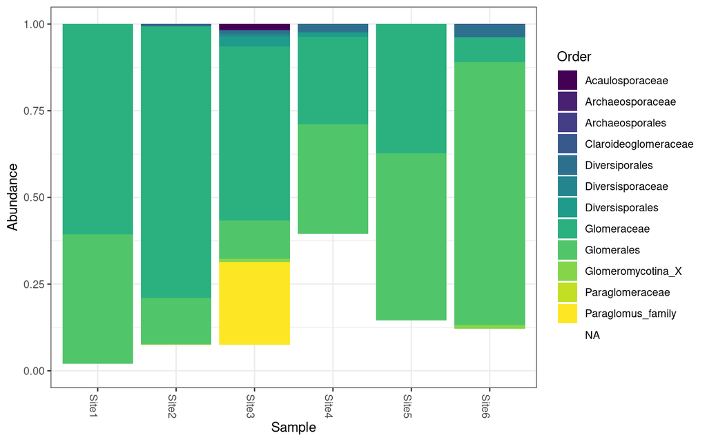

**Alpha diversity**

Effect of Shannon diversity on plant measures

**Table 4**

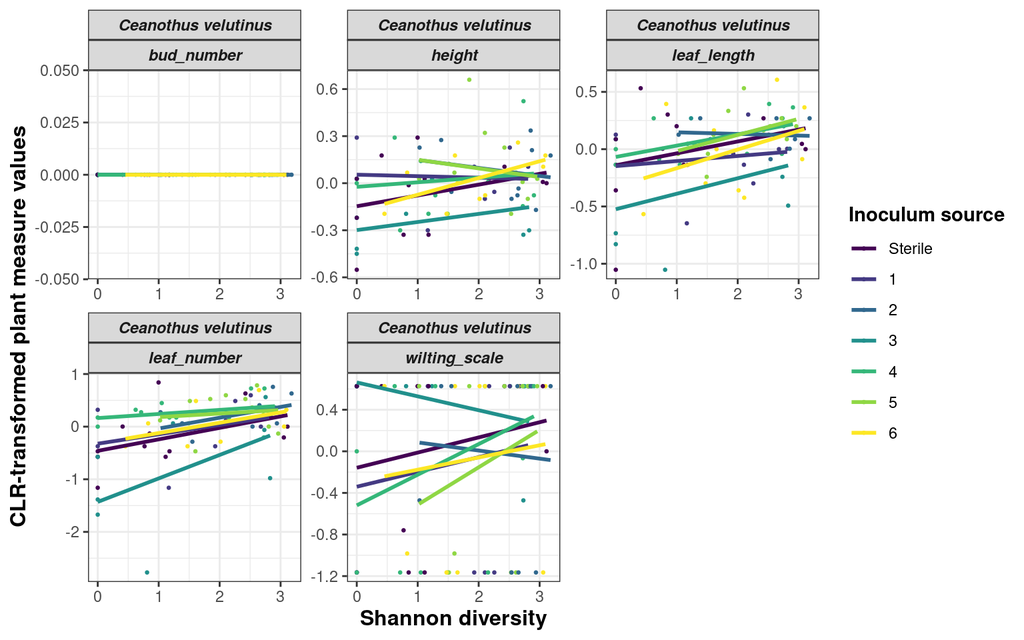

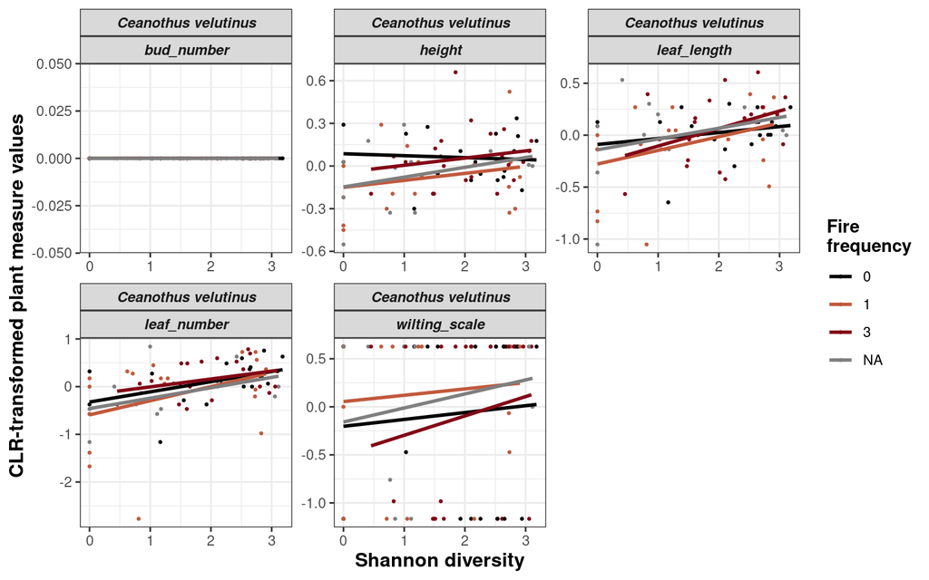

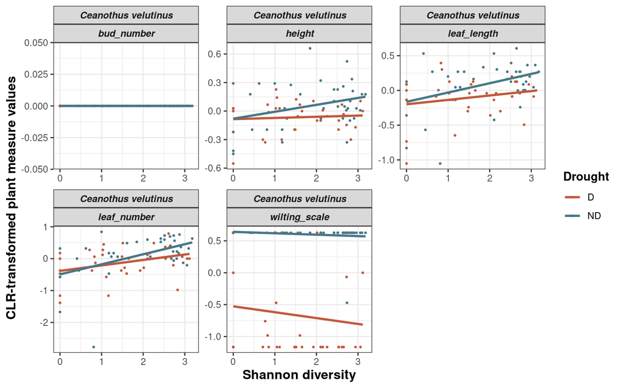

[output not shown]

| effect | group | term | estimate | std.error | statistic | df | p.value |
| --- | --- | --- | --- | --- | --- | --- | --- |
| fixed | NA | (Intercept) | -0.774 | 0.228 | -3.399 | 342 | 0.001 |
| fixed | NA | Shannon | 0.234 | 0.159 | 1.469 | 342 | 0.143 |
| fixed | NA | droughtND | 0.975 | 0.351 | 2.778 | 342 | 0.006 |
| fixed | NA | inoculum_site1 | 0.079 | 0.438 | 0.182 | 342 | 0.856 |
| fixed | NA | inoculum_site2 | 1.292 | 0.612 | 2.111 | 342 | 0.036 |
| fixed | NA | inoculum_site3 | 0.070 | 0.467 | 0.150 | 342 | 0.881 |
| fixed | NA | inoculum_site4 | 0.465 | 0.334 | 1.389 | 342 | 0.166 |
| fixed | NA | inoculum_site5 | 0.680 | 0.588 | 1.157 | 342 | 0.248 |
| fixed | NA | inoculum_site6 | 0.413 | 0.535 | 0.773 | 342 | 0.440 |
| fixed | NA | Shannon:droughtND | -0.151 | 0.222 | -0.677 | 342 | 0.499 |
| fixed | NA | Shannon:inoculum_site1 | -0.150 | 0.271 | -0.552 | 342 | 0.581 |
| fixed | NA | Shannon:inoculum_site2 | -0.579 | 0.297 | -1.945 | 342 | 0.053 |
| fixed | NA | Shannon:inoculum_site3 | -0.152 | 0.259 | -0.586 | 342 | 0.558 |
| fixed | NA | Shannon:inoculum_site4 | -0.238 | 0.227 | -1.045 | 342 | 0.297 |
| fixed | NA | Shannon:inoculum_site5 | -0.321 | 0.328 | -0.976 | 342 | 0.330 |
| fixed | NA | Shannon:inoculum_site6 | -0.258 | 0.295 | -0.876 | 342 | 0.382 |
| fixed | NA | droughtND:inoculum_site1 | 0.288 | 0.651 | 0.443 | 342 | 0.658 |
| fixed | NA | droughtND:inoculum_site2 | -1.133 | 1.025 | -1.105 | 342 | 0.270 |
| fixed | NA | droughtND:inoculum_site3 | -0.941 | 0.592 | -1.588 | 342 | 0.113 |
| fixed | NA | droughtND:inoculum_site4 | -0.362 | 0.581 | -0.623 | 342 | 0.534 |
| fixed | NA | droughtND:inoculum_site5 | 1.175 | 1.236 | 0.951 | 342 | 0.342 |
| fixed | NA | droughtND:inoculum_site6 | -0.880 | 0.740 | -1.190 | 342 | 0.235 |
| fixed | NA | Shannon:droughtND:inoculum_site1 | 0.013 | 0.358 | 0.035 | 342 | 0.972 |
| fixed | NA | Shannon:droughtND:inoculum_site2 | 0.577 | 0.445 | 1.298 | 342 | 0.195 |
| fixed | NA | Shannon:droughtND:inoculum_site3 | 0.346 | 0.335 | 1.030 | 342 | 0.304 |
| fixed | NA | Shannon:droughtND:inoculum_site4 | 0.290 | 0.334 | 0.867 | 342 | 0.386 |
| fixed | NA | Shannon:droughtND:inoculum_site5 | -0.365 | 0.555 | -0.658 | 342 | 0.511 |
| fixed | NA | Shannon:droughtND:inoculum_site6 | 0.506 | 0.389 | 1.302 | 342 | 0.194 |
| ran_pars | block | sd__(Intercept) | 0.000 | NA | NA | NA | NA |
| ran_pars | Residual | sd__Observation | 0.912 | NA | NA | NA | NA |

## **Comparison between inoculum and root communities**

### **Bacteria**

**Figure 5**

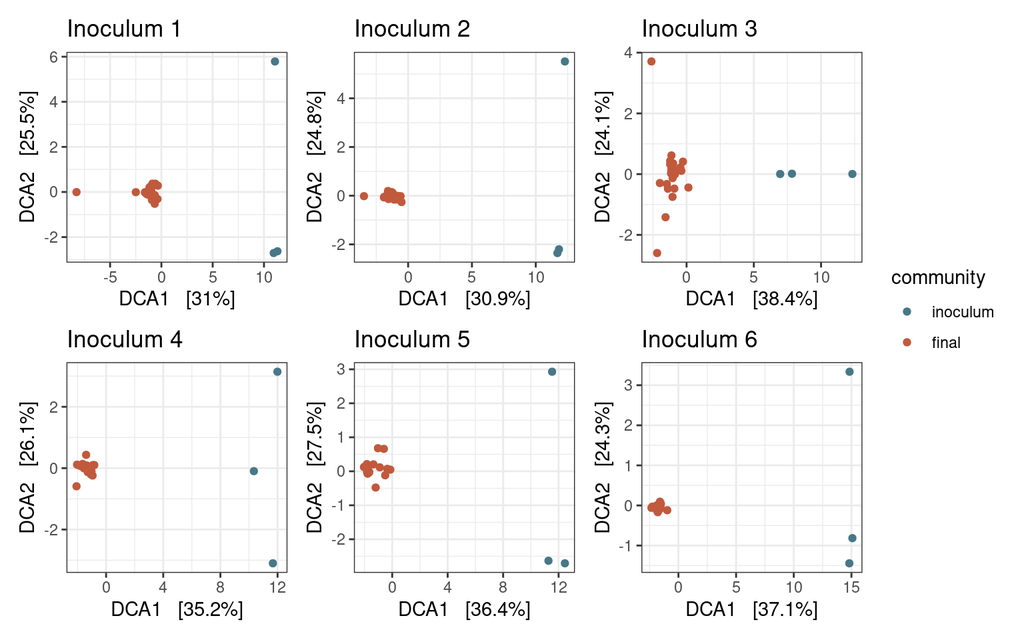

**Figure 6**

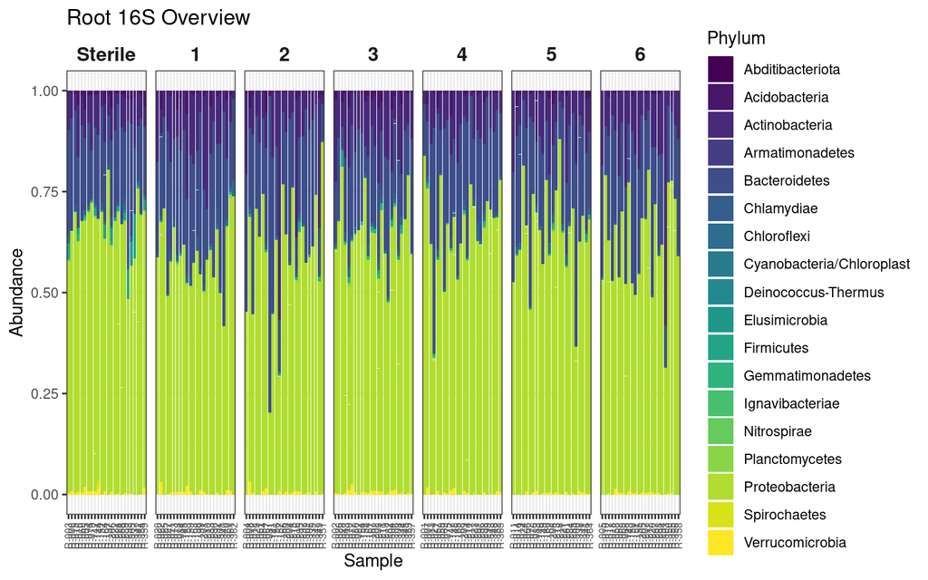

**Not all taxa in the inoculae were subsequently found in the root samples**

**Figure 7**

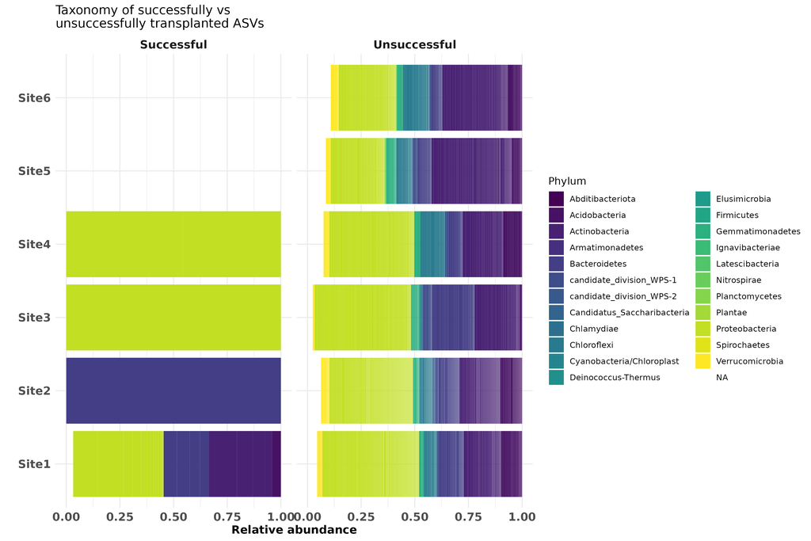

### **Fungi**

**Figure 8**

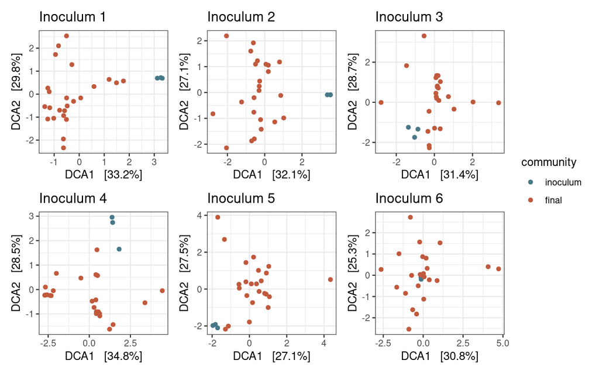

**Figure 9**

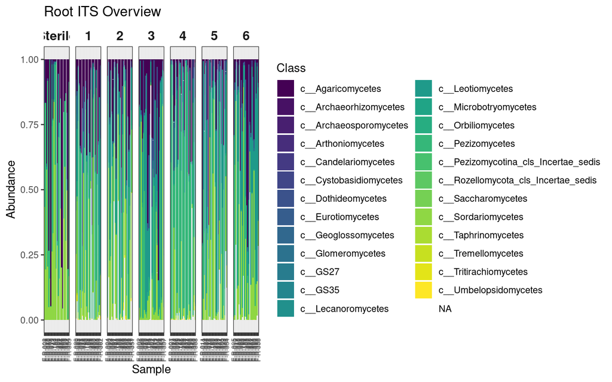

**Not all taxa in the inoculae were subsequently found in the root samples**

**Figure 10**

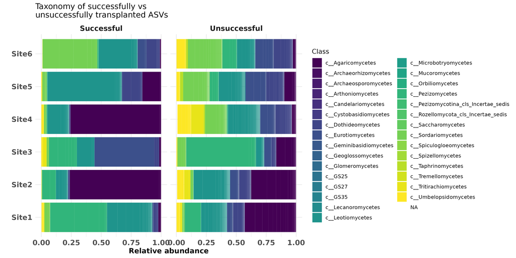

### **AMF**

**Figure 11**

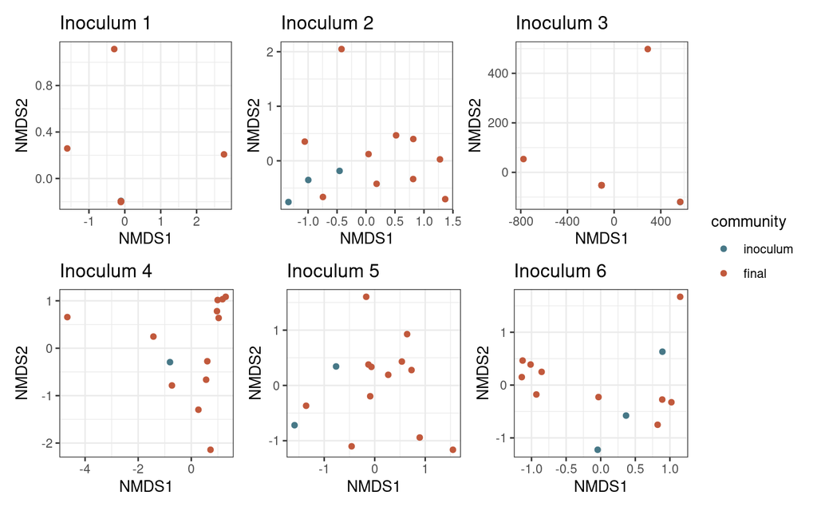

**Figure 12**

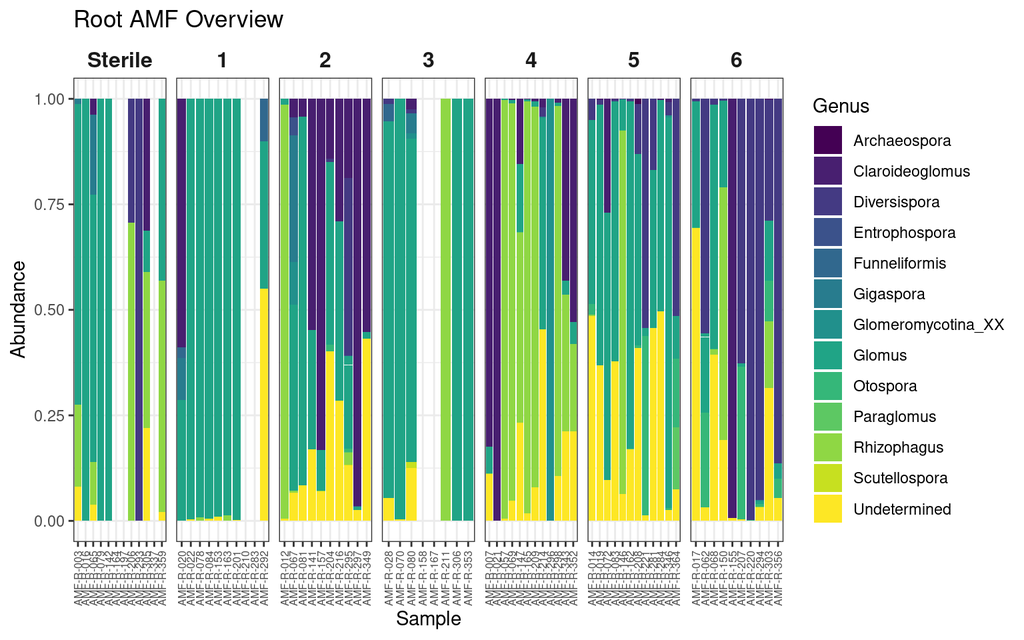

**Not all taxa in the inoculae were subsequently found in the root samples**

**Figure 13**

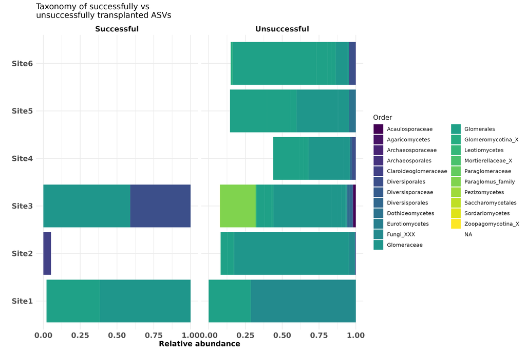

# **Microbial guilds**

## **Bacteria**

I couldn’t get a trustworthy annotation of “mutualists” for bacteria, but here are probable pathogens:

**Figure 14**

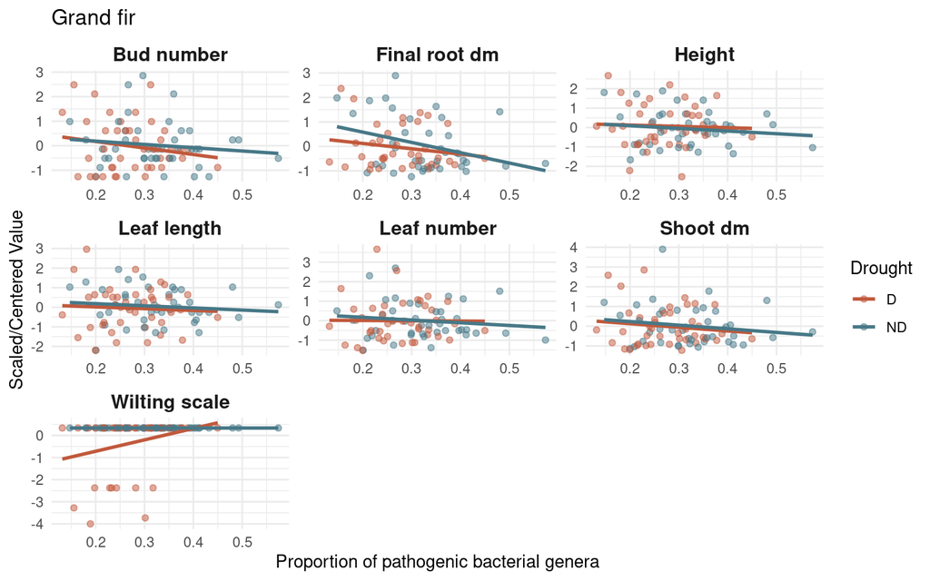

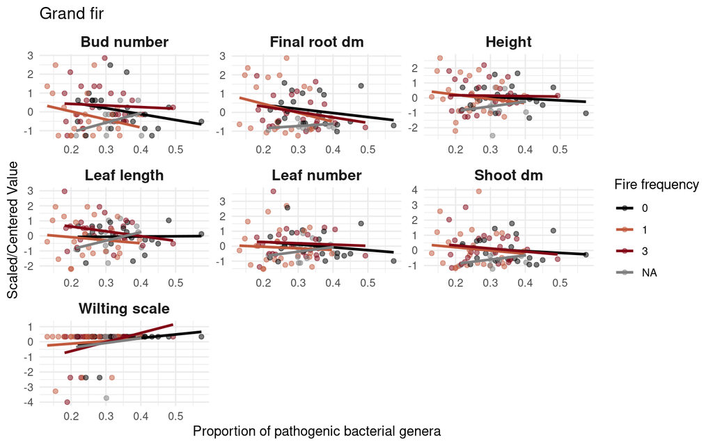

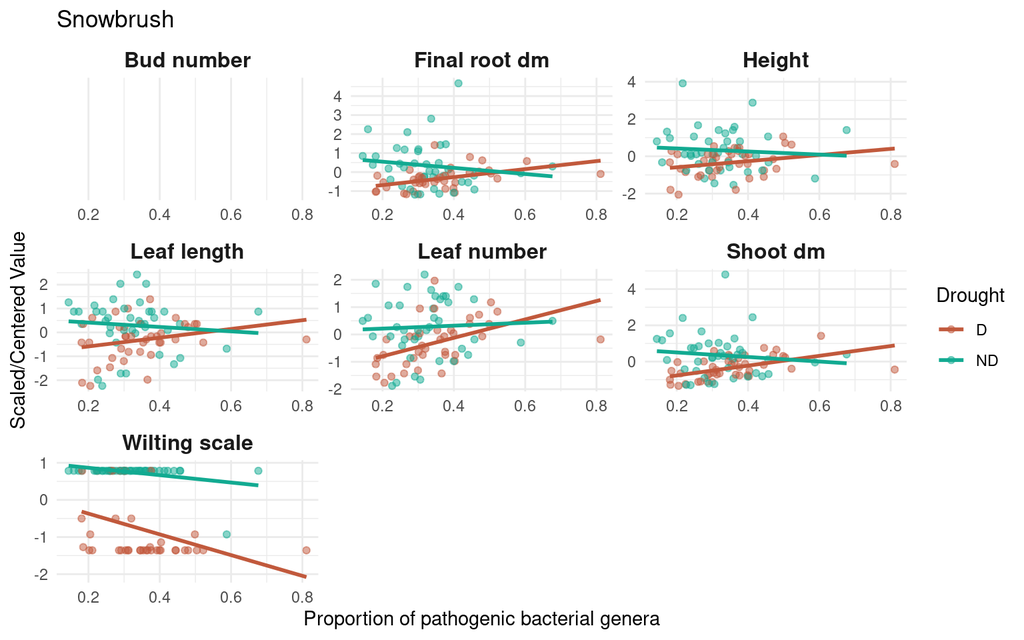

[figure not shown]

**Table 5**

```
## value ~ proportion_pathogen * drought + (1 | block)
## <environment: 0x55692d5791c0>
```

| effect | term | estimate | std.error | statistic | df | p.value | species |
| --- | --- | --- | --- | --- | --- | --- | --- |
| fixed | (Intercept) | -0.4579 | 0.2353 | -1.9458 | 27.6894 | 0.0619 | Ceanothus |
| fixed | proportion_pathogen | 0.1621 | 0.5053 | 0.3209 | 480.8904 | 0.7484 | Ceanothus |
| fixed | droughtND | 1.5430 | 0.2479 | 6.2243 | 477.2195 | 0.0000 | Ceanothus |
| fixed | proportion_pathogen:droughtND | -2.3112 | 0.6993 | -3.3049 | 477.2112 | 0.0010 | Ceanothus |
| fixed | (Intercept) | -0.3939 | 0.2931 | -1.3441 | 25.3702 | 0.1908 | Abies |
| fixed | proportion_pathogen | 1.0819 | 0.7509 | 1.4409 | 572.5931 | 0.1502 | Abies |
| fixed | droughtND | 0.6770 | 0.3000 | 2.2564 | 575.5163 | 0.0244 | Abies |
| fixed | proportion_pathogen:droughtND | -1.8231 | 0.9838 | -1.8530 | 574.8925 | 0.0644 | Abies |

## **Fungi**

How does the proportion of mutualist fungi relate to indicators of plant health?

In the following figure, the X-axis represents the proportion of fungi that could be identified to a mutualistic guild; the Y-axis represents the value of the various measures of plant success (facets). Y-axis scales vary between facets.

**Figure 15**

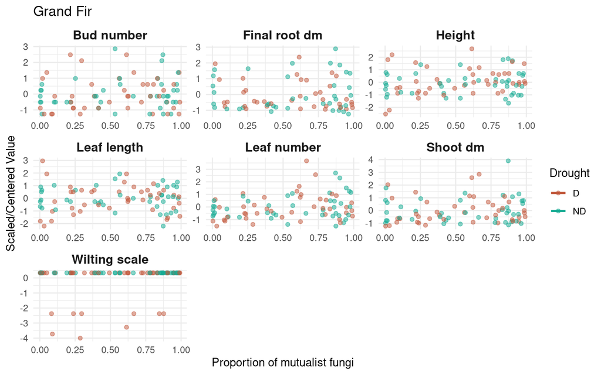

[figure not shown]

[figure not shown]

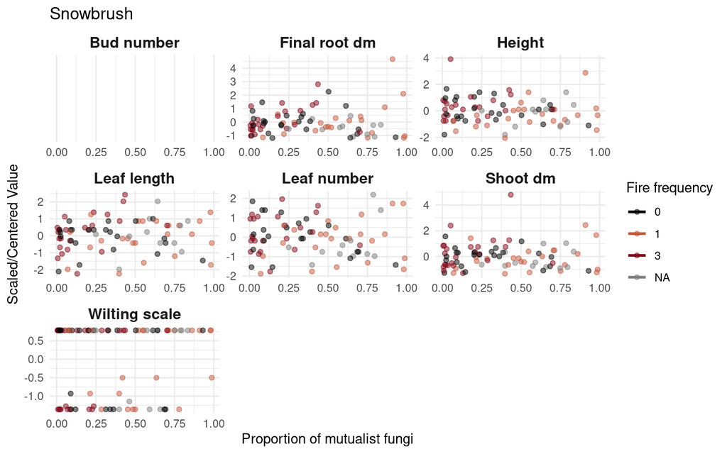